# Dave’s Analysis 2 for Data Mining HW 1

Reading in the restaurant data with the arules package.

```r
library(arules)
library(tidyverse)
menu <- read_csv("../restaurantData.csv")
```

## Background

A restaurant owner has a core menu that has remained constant throughout the past two years, while many other dishes have rotated on and off the menu. The owner has prepared a dataset of all orders containing elements of that core menu in which the customer also ordered wine. The dataset has 3 columns: orderNumber which identifies each individual person’s order at a table, order which itemizes the order’s components, and type which provides the type of item in the order (takes one of 3 values: ‘Meat’, ‘Side’, ‘Wine’).

## Task

The restaurant owner would like to add wine suggestions to the menu next to each meat and analyze her customer ordering habits in general. She is also interested in showing a picture of a popular meal of hers in an ad in Gourmet Diner magazine. Your job is to address her interests and also to report anything else of interest in terms of customer ordering habits, all in a nice summary report that is complete but to the point.

#### Overview of the dataset

```r
str(menu)
```

```
## Classes 'tbl_df', 'tbl' and 'data.frame':    26682 obs. of  3 variables:
##  $ order      : chr  "Mashed Potatoes" "Filet Mignon" "Blackstone Merlot" "Mashed Potatoes" ...
##  $ type       : chr  "Side" "Meat" "Wine" "Side" ...
##  $ orderNumber: int  14 14 14 22 22 22 27 27 27 76 ...
##  - attr(*, "spec")=List of 2
##   ..$ cols   :List of 3
##   .. ..$ order      : list()
##   .. .. ..- attr(*, "class")= chr  "collector_character" "collector"
##   .. ..$ type       : list()
##   .. .. ..- attr(*, "class")= chr  "collector_character" "collector"
##   .. ..$ orderNumber: list()
##   .. .. ..- attr(*, "class")= chr  "collector_integer" "collector"
##   ..$ default: list()
##   .. ..- attr(*, "class")= chr  "collector_guess" "collector"
##   ..- attr(*, "class")= chr "col_spec"
```

```r
head(menu)
```

| order | type | orderNumber |
| --- | --- | --- |
| Mashed Potatoes | Side | 14 |
| Filet Mignon | Meat | 14 |
| Blackstone Merlot | Wine | 14 |
| Mashed Potatoes | Side | 22 |
| Pork Tenderloin | Meat | 22 |
| Cantina Pinot Bianco | Wine | 22 |

#### Converting dataframe to transactions object and dropping type variable

```r
menu_2 <- menu %>%
  select(order,orderNumber) %>%
  modify_at("orderNumber", as.numeric) %>%
  modify_at("order", as_factor) %>%
  as.data.frame


trans <- as(split(menu_2[,"order"], menu_2[,"orderNumber"]), "transactions")
```

```r
inspect(trans[1:5])
```

```
##     items                  transactionID
## [1] {Mashed Potatoes,
##      Filet Mignon,
##      Blackstone Merlot}              14
## [2] {Mashed Potatoes,
##      Pork Tenderloin,
##      Cantina Pinot Bianco}           22
## [3] {Mashed Potatoes,
##      Pork Tenderloin,
##      Cantina Pinot Bianco}           27
## [4] {Mashed Potatoes,
##      Pork Tenderloin,
##      Cantina Pinot Bianco}           76
## [5] {Filet Mignon,
##      Caesar Salad,
##      Meiomi Pinot Noir}              115
```

#### Frequency of items

```r
itemFrequency(trans)
```

```
##      Mashed Potatoes         Filet Mignon    Blackstone Merlot
##           0.12577950           0.10930698           0.13213319
##      Pork Tenderloin Cantina Pinot Bianco         Caesar Salad
##           0.56312507           0.55288858           0.11624897
##    Meiomi Pinot Noir        Roast Chicken  Duckhorn Chardonnay
##           0.05047653           0.17625603           0.29215202
##                 Duck     Roasted Root Veg          Baked Beans
##           0.18049182           0.25614778           0.12942699
##              Risotto Steamed Seasonal Veg
##           0.13272150           0.23991058
```

#### Visualizing the frequencies

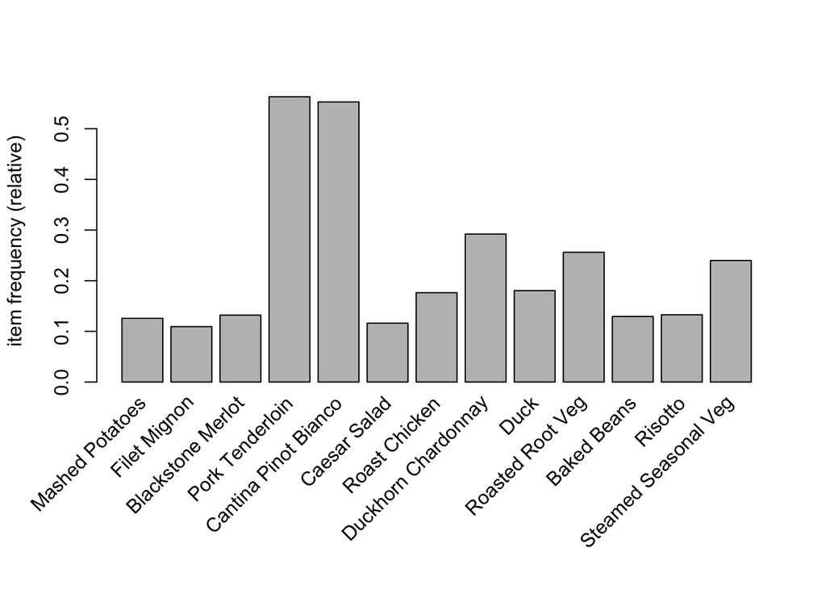

```r
itemFrequencyPlot(trans, support = 0.1)
```

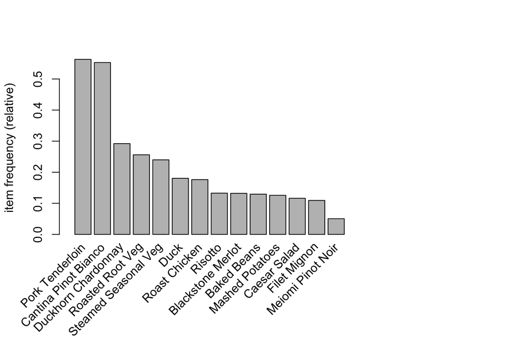

```r
itemFrequencyPlot(trans, topN = 20 )
```

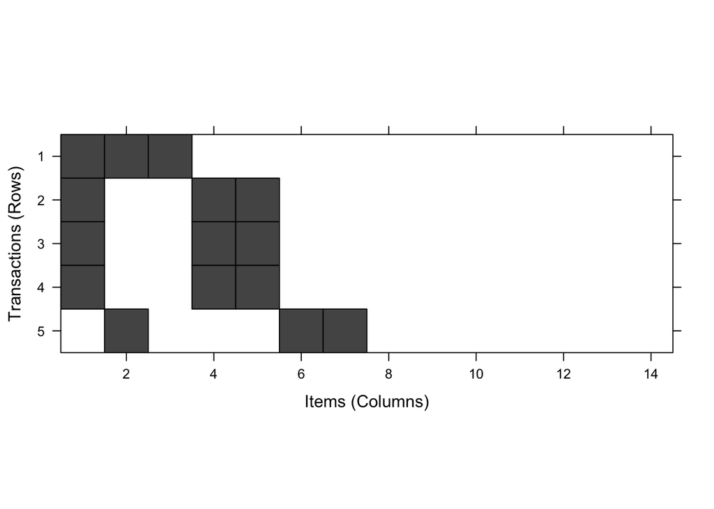

```r
image(trans[1:5])
```

#### Learning the association rules from the dataset with default settings

```r
apriori(trans)
```

```
## Apriori
##
## Parameter specification:
##  confidence minval smax arem  aval originalSupport maxtime support minlen
##         0.8    0.1    1 none FALSE            TRUE       5     0.1      1
##  maxlen target   ext
##      10  rules FALSE
##
## Algorithmic control:
##  filter tree heap memopt load sort verbose
##     0.1 TRUE TRUE  FALSE TRUE    2    TRUE
##
## Absolute minimum support count: 849
##
## set item appearances ...[0 item(s)] done [0.00s].
## set transactions ...[14 item(s), 8499 transaction(s)] done [0.00s].
## sorting and recoding items ... [13 item(s)] done [0.00s].
## creating transaction tree ... done [0.00s].
## checking subsets of size 1 2 3 done [0.00s].
## writing ... [7 rule(s)] done [0.00s].
## creating S4 object  ... done [0.00s].
```

```
## set of 7 rules
```

#### Setting the confidence levels and support to learn more rules

```r
rules <- apriori(trans, parameter = list(support = 0.006, confidence = 0.25, minlen = 2))
```

```
## Apriori
##
## Parameter specification:
##  confidence minval smax arem  aval originalSupport maxtime support minlen
##        0.25    0.1    1 none FALSE            TRUE       5   0.006      2
##  maxlen target   ext
##      10  rules FALSE
##
## Algorithmic control:
##  filter tree heap memopt load sort verbose
##     0.1 TRUE TRUE  FALSE TRUE    2    TRUE
##
## Absolute minimum support count: 50
##
## set item appearances ...[0 item(s)] done [0.00s].
## set transactions ...[14 item(s), 8499 transaction(s)] done [0.00s].
## sorting and recoding items ... [14 item(s)] done [0.00s].
## creating transaction tree ... done [0.00s].
## checking subsets of size 1 2 3 4 done [0.00s].
## writing ... [112 rule(s)] done [0.00s].
## creating S4 object  ... done [0.00s].
```

#### Checking out the rules

```r
summary(rules)
```

```
## set of 112 rules
##
## rule length distribution (lhs + rhs):sizes
##  2  3  4
## 37 71  4
##
##    Min. 1st Qu.  Median    Mean 3rd Qu.    Max.
##   2.000   2.000   3.000   2.705   3.000   4.000
##
## summary of quality measures:
##     support           confidence          lift            count
##  Min.   :0.006001   Min.   :0.2500   Min.   :0.4941   Min.   :  51.0
##  1st Qu.:0.012707   1st Qu.:0.3355   1st Qu.:1.0280   1st Qu.: 108.0
##  Median :0.030533   Median :0.5610   Median :1.6753   Median : 259.5
##  Mean   :0.053805   Mean   :0.5844   Mean   :2.2678   Mean   : 457.3
##  3rd Qu.:0.069126   3rd Qu.:0.8128   3rd Qu.:2.7318   3rd Qu.: 587.5
##  Max.   :0.521591   Max.   :0.9512   Max.   :6.6421   Max.   :4433.0
##
## mining info:
##   data ntransactions support confidence
##  trans          8499   0.006       0.25
```

#### 112 rules were discovered with parameter tweaks

```r
inspect(rules[1:10])
```

```
##      lhs                    rhs                    support    confidence
## [1]  {Meiomi Pinot Noir} => {Roast Chicken}        0.01882574 0.3729604
## [2]  {Meiomi Pinot Noir} => {Duck}                 0.01729615 0.3426573
## [3]  {Filet Mignon}      => {Blackstone Merlot}    0.09024591 0.8256189
## [4]  {Blackstone Merlot} => {Filet Mignon}         0.09024591 0.6829920
## [5]  {Filet Mignon}      => {Roasted Root Veg}     0.02906224 0.2658773
## [6]  {Caesar Salad}      => {Duckhorn Chardonnay}  0.03200377 0.2753036
## [7]  {Caesar Salad}      => {Cantina Pinot Bianco} 0.06577244 0.5657895
## [8]  {Caesar Salad}      => {Pork Tenderloin}      0.06683139 0.5748988
## [9]  {Mashed Potatoes}   => {Duckhorn Chardonnay}  0.03553359 0.2825070
## [10] {Mashed Potatoes}   => {Cantina Pinot Bianco} 0.07024356 0.5584659
##      lift      count
## [1]  2.1160148 160
## [2]  1.8984646 147
## [3]  6.2483842 767
## [4]  6.2483842 767
## [5]  1.0379840 247
## [6]  0.9423301 272
## [7]  1.0233336 559
## [8]  1.0209078 568
## [9]  0.9669864 302
## [10] 1.0100875 597
```

#### Inspecting with sort by lift.

```r
inspect(sort(rules, by = "lift")[1:10])
```

```
##      lhs                       rhs                     support confidence     lift count
## [1]  {Blackstone Merlot,
##       Risotto}              => {Filet Mignon}      0.012472056  0.7260274 6.642096   106
## [2]  {Filet Mignon,
##       Roasted Root Veg}     => {Blackstone Merlot} 0.025061772  0.8623482 6.526355   213
## [3]  {Blackstone Merlot,
##       Roasted Root Veg}     => {Filet Mignon}      0.025061772  0.7076412 6.473889   213
## [4]  {Filet Mignon,
##       Steamed Seasonal Veg} => {Blackstone Merlot} 0.022708554  0.8354978 6.323149   193
## [5]  {Filet Mignon,
##       Risotto}              => {Blackstone Merlot} 0.012472056  0.8281250 6.267350   106
## [6]  {Filet Mignon}         => {Blackstone Merlot} 0.090245911  0.8256189 6.248384   767
## [7]  {Blackstone Merlot}    => {Filet Mignon}      0.090245911  0.6829920 6.248384   767
## [8]  {Blackstone Merlot,
##       Steamed Seasonal Veg} => {Filet Mignon}      0.022708554  0.6771930 6.195332   193
## [9]  {Mashed Potatoes,
##       Filet Mignon}         => {Blackstone Merlot} 0.010942464  0.8157895 6.173994    93
## [10] {Filet Mignon,
##       Caesar Salad}         => {Blackstone Merlot} 0.009883516  0.8155340 6.172060    84
```

#### Find unique wines

```r
wine <- menu %>%
  filter(type == "Wine") %>%
  distinct(order) %>%
  pull()
wine
```

```
## [1] "Blackstone Merlot"    "Cantina Pinot Bianco" "Meiomi Pinot Noir"
## [4] "Duckhorn Chardonnay"
```

#### Find subset of rules for 4 wine types

```r
merlot <- subset(rules, items %in% wine[1])
inspect(sort(merlot, by = "lift")[1:10])
```

```
##      lhs                       rhs                     support confidence     lift count
## [1]  {Blackstone Merlot,
##       Risotto}              => {Filet Mignon}      0.012472056  0.7260274 6.642096   106
## [2]  {Filet Mignon,
##       Roasted Root Veg}     => {Blackstone Merlot} 0.025061772  0.8623482 6.526355   213
## [3]  {Blackstone Merlot,
##       Roasted Root Veg}     => {Filet Mignon}      0.025061772  0.7076412 6.473889   213
## [4]  {Filet Mignon,
##       Steamed Seasonal Veg} => {Blackstone Merlot} 0.022708554  0.8354978 6.323149   193
## [5]  {Filet Mignon,
##       Risotto}              => {Blackstone Merlot} 0.012472056  0.8281250 6.267350   106
## [6]  {Filet Mignon}         => {Blackstone Merlot} 0.090245911  0.8256189 6.248384   767
## [7]  {Blackstone Merlot}    => {Filet Mignon}      0.090245911  0.6829920 6.248384   767
## [8]  {Blackstone Merlot,
##       Steamed Seasonal Veg} => {Filet Mignon}      0.022708554  0.6771930 6.195332   193
## [9]  {Mashed Potatoes,
##       Filet Mignon}         => {Blackstone Merlot} 0.010942464  0.8157895 6.173994    93
## [10] {Filet Mignon,
##       Caesar Salad}         => {Blackstone Merlot} 0.009883516  0.8155340 6.172060    84
```

6.25 times more likely to see a Blackstone Merlot with Filet Mignon than we are to see one at random.

```r
pinot_bianco <- subset(rules, items %in% wine[2])
inspect(sort(pinot_bianco, by = "lift")[1:20])
```

```
##      lhs                       rhs                        support confidence     lift count
## [1]  {Cantina Pinot Bianco,
##       Duckhorn Chardonnay}  => {Roast Chicken}        0.007177315  0.5213675 2.958012    61
## [2]  {Pork Tenderloin,
##       Cantina Pinot Bianco,
##       Duckhorn Chardonnay}  => {Roast Chicken}        0.006471350  0.5092593 2.889315    55
## [3]  {Pork Tenderloin,
##       Cantina Pinot Bianco,
##       Roast Chicken}        => {Duckhorn Chardonnay}  0.006471350  0.7971014 2.728379    55
## [4]  {Cantina Pinot Bianco,
##       Duckhorn Chardonnay}  => {Duck}                 0.006000706  0.4358974 2.415054    51
## [5]  {Mashed Potatoes,
##       Pork Tenderloin}      => {Cantina Pinot Bianco} 0.065654783  0.9378151 1.696210   558
## [6]  {Pork Tenderloin,
##       Baked Beans}          => {Cantina Pinot Bianco} 0.068831627  0.9375000 1.695640   585
## [7]  {Cantina Pinot Bianco,
##       Steamed Seasonal Veg} => {Pork Tenderloin}      0.123896929  0.9512195 1.689180  1053
## [8]  {Pork Tenderloin,
##       Duck}                 => {Cantina Pinot Bianco} 0.008118602  0.9324324 1.686474    69
## [9]  {Pork Tenderloin,
##       Risotto}              => {Cantina Pinot Bianco} 0.068360984  0.9310897 1.684046   581
## [10] {Cantina Pinot Bianco,
##       Risotto}              => {Pork Tenderloin}      0.068360984  0.9462541 1.680362   581
## [11] {Cantina Pinot Bianco} => {Pork Tenderloin}      0.521590775  0.9433922 1.675280  4433
## [12] {Pork Tenderloin}      => {Cantina Pinot Bianco} 0.521590775  0.9262432 1.675280  4433
## [13] {Cantina Pinot Bianco,
##       Roasted Root Veg}     => {Pork Tenderloin}      0.133427462  0.9426434 1.673950  1134
## [14] {Cantina Pinot Bianco,
##       Baked Beans}          => {Pork Tenderloin}      0.068831627  0.9420290 1.672859   585
## [15] {Pork Tenderloin,
##       Roasted Root Veg}     => {Cantina Pinot Bianco} 0.133427462  0.9242054 1.671594  1134
## [16] {Pork Tenderloin,
##       Caesar Salad}         => {Cantina Pinot Bianco} 0.061654312  0.9225352 1.668573   524
## [17] {Cantina Pinot Bianco,
##       Caesar Salad}         => {Pork Tenderloin}      0.061654312  0.9373882 1.664618   524
## [18] {Mashed Potatoes,
##       Cantina Pinot Bianco} => {Pork Tenderloin}      0.065654783  0.9346734 1.659797   558
## [19] {Pork Tenderloin,
##       Steamed Seasonal Veg} => {Cantina Pinot Bianco} 0.123896929  0.9156522 1.656124  1053
## [20] {Blackstone Merlot,
##       Cantina Pinot Bianco} => {Pork Tenderloin}      0.006000706  0.9272727 1.646655    51
```

1.67 times more likely to see a Cantina Pinot Bianco with Pork Tenderloin than we are to see one at random.

```r
pinot_noir <- subset(rules, items %in% wine[3])
inspect(sort(pinot_noir, by = "lift"))
```

```
##     lhs                    rhs             support    confidence lift
## [1] {Meiomi Pinot Noir} => {Roast Chicken} 0.01882574 0.3729604  2.116015
## [2] {Meiomi Pinot Noir} => {Duck}          0.01729615 0.3426573  1.898465
##     count
## [1] 160
## [2] 147
```

No values for Meiomi Pinot Noir in the consequent(RHS).

```r
chardonnay <- subset(rules, items %in% wine[4])
inspect(sort(chardonnay, by = "lift")[1:20])
```

```
##      lhs                       rhs                       support confidence     lift count
## [1]  {Duckhorn Chardonnay,
##       Steamed Seasonal Veg} => {Roast Chicken}       0.037298506  0.5257048 2.982620   317
## [2]  {Cantina Pinot Bianco,
##       Duckhorn Chardonnay}  => {Roast Chicken}       0.007177315  0.5213675 2.958012    61
## [3]  {Caesar Salad,
##       Duckhorn Chardonnay}  => {Roast Chicken}       0.016590187  0.5183824 2.941076   141
## [4]  {Pork Tenderloin,
##       Cantina Pinot Bianco,
##       Duckhorn Chardonnay}  => {Roast Chicken}       0.006471350  0.5092593 2.889315    55
## [5]  {Roast Chicken,
##       Roasted Root Veg}     => {Duckhorn Chardonnay} 0.037298506  0.8342105 2.855399   317
## [6]  {Mashed Potatoes,
##       Duckhorn Chardonnay}  => {Duck}                0.018119779  0.5099338 2.825246   154
## [7]  {Roast Chicken,
##       Steamed Seasonal Veg} => {Duckhorn Chardonnay} 0.037298506  0.8170103 2.796525   317
## [8]  {Duckhorn Chardonnay,
##       Roasted Root Veg}     => {Roast Chicken}       0.037298506  0.4914729 2.788403   317
## [9]  {Duck,
##       Risotto}              => {Duckhorn Chardonnay} 0.020825980  0.8119266 2.779124   177
## [10] {Duckhorn Chardonnay,
##       Risotto}              => {Duck}                0.020825980  0.5000000 2.770209   177
## [11] {Pork Tenderloin,
##       Roast Chicken}        => {Duckhorn Chardonnay} 0.007294976  0.8051948 2.756082    62
## [12] {Roast Chicken}        => {Duckhorn Chardonnay} 0.141428403  0.8024032 2.746526  1202
## [13] {Duckhorn Chardonnay}  => {Roast Chicken}       0.141428403  0.4840918 2.746526  1202
## [14] {Caesar Salad,
##       Roast Chicken}        => {Duckhorn Chardonnay} 0.016590187  0.8011364 2.742190   141
## [15] {Pork Tenderloin,
##       Cantina Pinot Bianco,
##       Roast Chicken}        => {Duckhorn Chardonnay} 0.006471350  0.7971014 2.728379    55
## [16] {Roast Chicken,
##       Baked Beans}          => {Duckhorn Chardonnay} 0.017178492  0.7891892 2.701296   146
## [17] {Duckhorn Chardonnay,
##       Baked Beans}          => {Roast Chicken}       0.017178492  0.4755700 2.698177   146
## [18] {Roast Chicken,
##       Risotto}              => {Duckhorn Chardonnay} 0.017296152  0.7736842 2.648225   147
## [19] {Mashed Potatoes,
##       Roast Chicken}        => {Duckhorn Chardonnay} 0.015766561  0.7486034 2.562376   134
## [20] {Duckhorn Chardonnay,
##       Baked Beans}          => {Duck}                0.016472526  0.4560261 2.526575   140
```

2.75 times more likely to see a Duckhorn Chardonnay with Roast Chicken than we are to see one at random.